## In Development CNV Evidence Plot Code

This code was intended to be executed within an R `plumbr` API framework. It cannot be run as is without access to the API database or even with access to the API database as it was not every incorporated into the `OpenPedCan-api`. However this Rmd script does it’s best to demonstrate what each script does and provide an example output.

### Step 1: Fetching Data from the Database

The evidence page view in Open Targets is for data from specific gene and disease. The `cnv_cnv_evidence_summary` database contains information for all disease and all genes; a very limited plain-text version of the database for the 3 demo genes is in the `input/` folder and is read in in the chunk below.

```r
vroom('input/example_cnv_cnv_evidence_summary.csv') -> cnv_evidence_database_example
```

In the API, the script `src/get_cnv_evidence_tbl.R` would query the database and filter for the gene and disease requested. Constructing the database and running the API is beyond the scope of this repository so for the sake of executing the plot and summary table scripts, the example database is filtered normally using tidyverse functions.

`get_cnv_evidence_tbl()`

Args:

- ensg_id: a single character value of gene ENSG ID. REQUIRED.
- relapse_sample_group: a single character value with the following choices. REQUIRED.
  - “exclude”: Exclude relapse tumors. Does NOT raise error if there is no relapse tumor.
  - “require”: Require all relapse tumors. Raise error if there is no relapse tumor.
- efo_id: a single character value of EFO ID. REQUIRED.
- gene_symbol: NULL or a single character value of gene symbol. Default is NULL, which is to select the first sorted gene symbol when one ENSG ID maps to multiple gene symbols. If gene_symbol is not NULL, the (efo_id, gene_symbol) tuple is selected when one ENSG ID maps to multiple gene symbols.

Returns a tibble with the following columns:

- cohort: a single cohort. If the input efo_id has more than one histology_df cohorts, e.g. GMKF and TARGET, include an additional cohort “All Cohorts” in the result table.
- EFO: a single EFO ID
- MONDO: a single MONDO ID
- Disease: a single Disease/cancer_group
- cnv_type: categorical descriptor of the copy number variant, one of deep deletion (no copies), loss (fewer copies than ploidy), neutral (same number of copies as ploidy), gain (up to two times ploidy), amplification (greater than two times ploidy)
- sample_count: a numeric count of the number of samples with an alteration in the given category
- Gene_Ensembl_ID: a single ENSG ID
- Gene_symbol: a single gene symbol
- cancer_status: whether the tumor is primary or relapse. Will contain one or both of those options, depending on the type requested

```r
### what the call would theoretically be in the database
# get_cnv_evidence_tbl(ensg_id = 'ENSG00000134323',
#                      relapse_sample_group = 'exclude',
#                      efo_id = 'EFO_0000621')

### filter for one disease and one gene
cnv_evidence_database_example %>%
  filter(ensembl == 'ENSG00000134323',
         specimen_descriptor == 'Primary Tumor',
         efo_code == 'EFO_0000621') -> cnv_evidence_tbl
```

### Step 2: Plot

`get_cnv_evidence_plot()`

Args:

- `cnv_evidence_tbl`: a tibble of a single gene, one disease, with multiple cohorts if they exist for that disease and returned by `get_cnv_evidence_tbl()`.

Returns a ggplot stacked bar plot of a single gene and one disease, with multiple cohorts if they exist for that gene

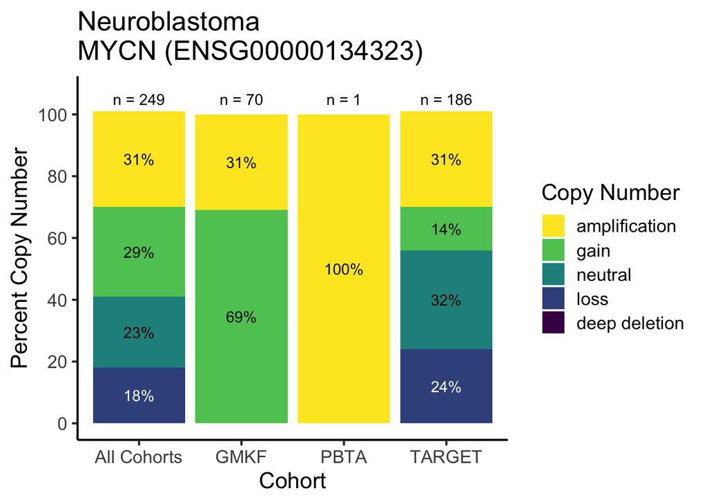

```r
get_cnv_evidence_plot(cnv_evidence_tbl) -> cnv_evidence_plot
cnv_evidence_plot
```

```r
ggsave('plots/example_cnv_evidence_plot.png')
```

### Step 3: Return the Plot Data Summary Table

`get_cnv_evidence_summary_tbl()`

Args:

- `cnv_evidence_tbl`: a tibble of a single gene, one disease, with multiple cohorts if they exist for that disease and returned by `get_cnv_evidence_tbl()`.

Returns a summary table of a single gene and one disease, with multiple cohorts if they exist for that gene

```r
get_cnv_evidence_summary_tbl(cnv_evidence_tbl) -> cnv_evidence_summary_tbl
cnv_evidence_summary_tbl
```

```
## # A tibble: 11 × 14
##    ensembl         gene_symbol cancer_group  status   cohort specimen_descriptor
##    <chr>           <chr>       <chr>         <fct>    <fct>  <chr>
##  1 ENSG00000134323 MYCN        Neuroblastoma amplifi… All C… Primary Tumor
##  2 ENSG00000134323 MYCN        Neuroblastoma amplifi… GMKF   Primary Tumor
##  3 ENSG00000134323 MYCN        Neuroblastoma amplifi… PBTA   Primary Tumor
##  4 ENSG00000134323 MYCN        Neuroblastoma amplifi… TARGET Primary Tumor
##  5 ENSG00000134323 MYCN        Neuroblastoma gain     All C… Primary Tumor
##  6 ENSG00000134323 MYCN        Neuroblastoma gain     GMKF   Primary Tumor
##  7 ENSG00000134323 MYCN        Neuroblastoma gain     TARGET Primary Tumor
##  8 ENSG00000134323 MYCN        Neuroblastoma loss     All C… Primary Tumor
##  9 ENSG00000134323 MYCN        Neuroblastoma loss     TARGET Primary Tumor
## 10 ENSG00000134323 MYCN        Neuroblastoma neutral  All C… Primary Tumor
## 11 ENSG00000134323 MYCN        Neuroblastoma neutral  TARGET Primary Tumor
## # ℹ 8 more variables: sample_count <dbl>, efo_code <chr>, mondo_code <chr>,
## #   ncit_code <chr>, version <chr>, group_count <dbl>, percentage <dbl>,
## #   label <chr>
```

```r
write_tsv(cnv_evidence_summary_tbl, 'plots/example_cnv_evidence_summary_tbl.tsv')
```